# CSCI E-63C: Week 4 Problem Set

Erik Lee

# Preface

This week problem set is focused on using resampling (specifically, bootstrap) to estimate and compare training and test error of linear models with progressively increasing number of variables as linear and quadratic (ultimately all pairwise combinations) terms. The goal is to advance your familiarity with fitting multiple regression models, to develop hands on experience with use of resampling and to observe first hand the discrepancy in the trending of training and test error with the increase in model complexity.

The problem set will use new dataset available at UCI ML repository – https://archive.ics.uci.edu/ml/datasets/Computer+Hardware – on CPU performance (from the quaint times of processors speed in single digits MHz). As before, you are encouraged to download and use a copy local to your machine to decrease the dependency on availability of UCI ML website. For the same purposes a copy of this dataset is also made available at this course website in canvas. Below main steps of this week problem set are illustrated on a simulated dataset.

For the purposes of this illustration we start with developing an R function that produces a simulated dataset for given numbers of observations and variables. Its output includes given number of i.i.d. standard normal deviates as well as all their pairwise combinations in addition to the outcome as an unweighted average of a given subset of these variables with controlled amount of gaussian noise added to it. Admittedly, gross oversimplification of any real-life dataset typically encountered in the wild, but it will suffice for our purposes (to see through resampling the divergence of training and test errors with increasing model complexity):

```r
simuLinQuadDat <- function(inpNobs=100, inpNlinVars=5, inpYidx=1:2, inpSDerr=0.5) {
  # Nobs x Nvars matrix of linear terms:
  xTmp <- matrix(rnorm(inpNobs*inpNlinVars),ncol=inpNlinVars)
  # Make all pairwise products of linear terms,
  # X1*X1, X1*X2, X1*X3, ..., Xn*Xn:
  x2Tmp <- NULL
  tmpCnms <- NULL
  # for each linear term:
  for ( iTmp in 1:dim(xTmp)[2] ) {
    # multiply it by itself and all other terms,
    # excluding already generated pairwise combinations:
    for ( jTmp in iTmp:dim(xTmp)[2] ) {
      x2Tmp <- cbind(x2Tmp,xTmp[,iTmp]*xTmp[,jTmp])
      # maintain vector of column names for quadratic
      # terms along the way:
      tmpCnms <- c(tmpCnms,paste0("X",iTmp,"X",jTmp))
    }
  }
  # name attributes in the matrix of quadratic terms:
  colnames(x2Tmp) <- tmpCnms
  # create outcome as a sum of an unweighted average of
  # specified columns and controlled amount
  # of gaussian noise:
  yTmp <- rowMeans(cbind(xTmp,x2Tmp)[,inpYidx])+rnorm(inpNobs,sd=inpSDerr)
  # return data.frame with outcome as a first column,
  # followed by linear, then by quadratic terms:
  data.frame(Y=yTmp,xTmp,x2Tmp)
}
```

For the purposes of this problem set you will have the computer hardware dataset to work with, so that you won’t have to simulate data from standard normal. However, this problem set will ask you to include all pairwise products of its continuous attributes in the model, so some aspects of the above code will have to be incorporated in your work.

Now, let’s simulate a dataset using the default parameters, briefly look it over and fit a couple of linear models to it (notice the effect of specifying `fig.width` and ‘fig.height’ in triple-backticks curly braces clause demarcating R code below that govern the size and dimensions of the figure produced):

```r
simDat <- simuLinQuadDat()
class(simDat)
```

```
## [1] "data.frame"
```

```r
dim(simDat)
```

```
## [1] 100  21
```

```r
head(simDat)
```

```
##             Y          X1         X2          X3         X4          X5
## 1 -0.17068520 -0.63999595  0.0682778  0.01282702 -0.8200967 -0.03555045
## 2 -0.04828908 -0.03842739  0.5024625 -0.12511272 -0.5927364 -0.72416059
## 3 -0.03094728  0.41672419  0.3226444 -0.26690050  2.0543286 -2.64556967
## 4  1.71821079  1.28031627  0.9911166  0.30525556  0.7543668 -0.15727889
## 5 -0.36929643 -0.74670900 -0.2373398 -0.86545921 -1.2758724 -0.48127700
## 6 -0.50856622 -0.65449232 -1.2348296 -0.05151617 -0.6075683  0.49027596
##          X1X1        X1X2         X1X3       X1X4        X1X5        X2X2
## 1 0.409594817 -0.04369751 -0.008209239 0.52485858  0.02275214 0.004661858
## 2 0.001476664 -0.01930832  0.004807755 0.02277731  0.02782760 0.252468582
## 3 0.173659048  0.13445374 -0.111223894 0.85608843 -1.10247287 0.104099426
## 4 1.639209752  1.26894270  0.390823666 0.96582812 -0.20136672 0.982312101
## 5 0.557574332  0.17722377  0.646246185 0.95270541  0.35937387 0.056330182
## 6 0.428360199  0.80818648  0.033716940 0.39764876 -0.32088185 1.524804085
##            X2X3       X2X4         X2X5         X3X3        X3X4
## 1  0.0008758005 -0.0559944 -0.002427306 0.0001645324 -0.01051940
## 2 -0.0628644547 -0.2978278 -0.363863554 0.0156531939  0.07415887
## 3 -0.0861139593  0.6628177 -0.853578312 0.0712358774 -0.54830134
## 4  0.3025438551  0.7476655 -0.155881714 0.0931809596  0.23027467
## 5  0.2054079199  0.3028153  0.114226188 0.7490196522  1.10421553
## 6  0.0636136945  0.7502432 -0.605407257 0.0026539161  0.03129959
##            X3X5      X4X4       X4X5        X5X5
## 1 -0.0004560062 0.6725586  0.0291548 0.001263834
## 2  0.0906017045 0.3513365  0.4292364 0.524408560
## 3  0.7061038712 4.2202662 -5.4348696 6.999038900
## 4 -0.0480102553 0.5690693 -0.1186460 0.024736648
## 5  0.4165256124 1.6278504  0.6140480 0.231627548
## 6 -0.0252571414 0.3691392 -0.2978761 0.240370518
```

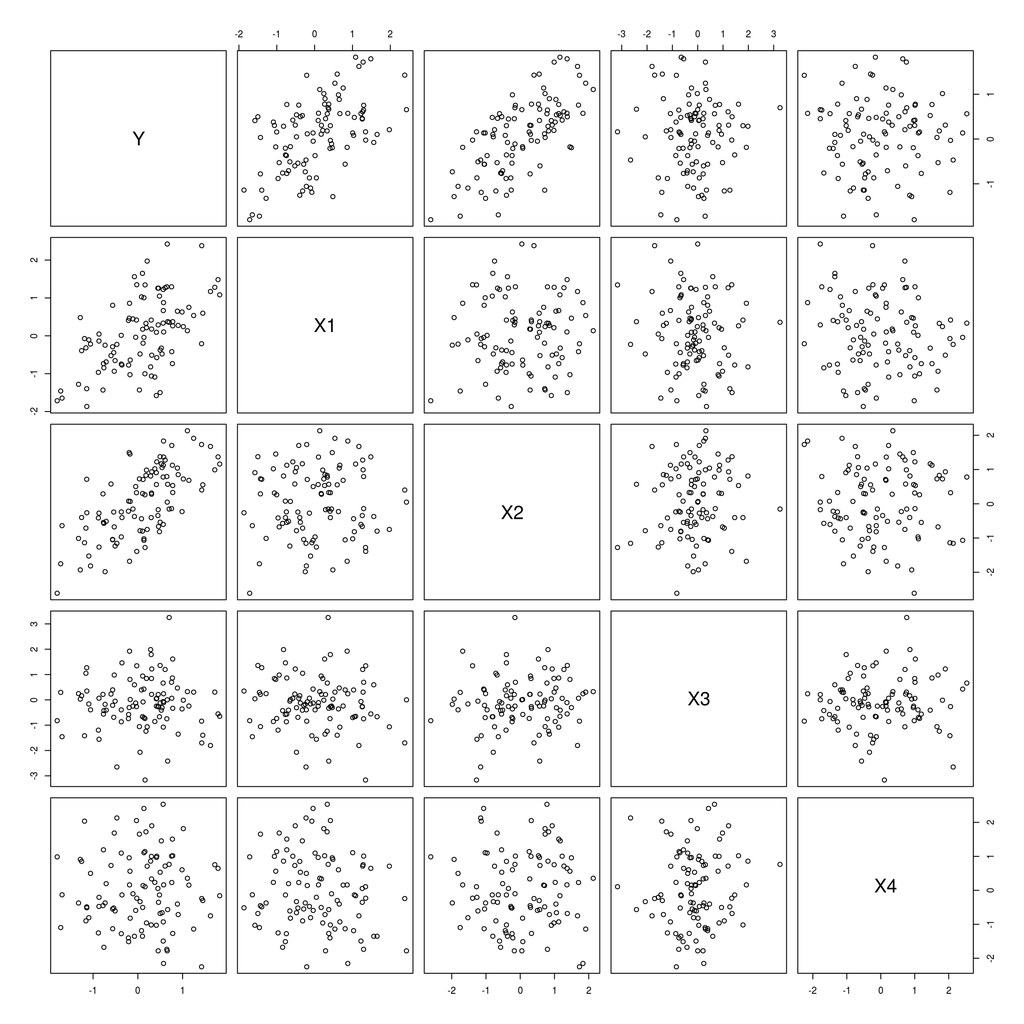

```r
pairs(simDat[,1:5])
```

For defaults of $n=100$ observations and $k=5$ linear terms it returns a `data.frame` of $n$ rows and $p=1+k+k*(k+1)/2$ columns (outcome, linear terms, all pairwise quadratic combinations). Because, by default, the outcome is the average of first two attributes (with added noise), they show noticeable correlation with the outcome, unlike others.

For the purposes of model fitting, the terms can be either explicitly provided by the formula:

```r
lm(Y~X1+X2+X1X1+X1X2+X2X2,simDat)
```

```
##
## Call:
## lm(formula = Y ~ X1 + X2 + X1X1 + X1X2 + X2X2, data = simDat)
##
## Coefficients:
## (Intercept)           X1           X2         X1X1         X1X2
##    0.061865     0.448580     0.512077    -0.026622    -0.017640
##        X2X2
##   -0.003525
```

or, by providing `lm()` with a subset of columns in the input data and using formula that incorporates all terms from the input data in the model:

```r
lm(Y~.,simDat[,c("Y","X1","X2","X1X1","X1X2","X2X2")])
```

```
##
## Call:
## lm(formula = Y ~ ., data = simDat[, c("Y", "X1", "X2", "X1X1",
##     "X1X2", "X2X2")])
##
## Coefficients:
## (Intercept)           X1           X2         X1X1         X1X2
##    0.061865     0.448580     0.512077    -0.026622    -0.017640
##        X2X2
##   -0.003525
```

or, equivalently, by numeric indices into `data.frame` columns:

```r
lm(Y~.,simDat[,c(1:3,7,8,12)])
```

```
##
## Call:
## lm(formula = Y ~ ., data = simDat[, c(1:3, 7, 8, 12)])
##
## Coefficients:
## (Intercept)           X1           X2         X1X1         X1X2
##    0.061865     0.448580     0.512077    -0.026622    -0.017640
##        X2X2
##   -0.003525
```

*Explicit* inclusion of model terms in the formula is the most suitable for interactive model fitting, easiest to read and understand and overall is the recommended approach for these reasons. Using `as.formula` and `paste` with suitable value for `collapse` (e.g. `"+"`, `"*"` and/or `":"`) called on a proper subset of data frame column names one can compile and parse model formulas *dynamically* – for instance, the code chunk below fits exactly the same model as the code chunk above:

```r
lm(as.formula(paste0("Y~",paste(colnames(simDat)[c(2:3,7,8,12)],collapse="+"))),simDat)
```

```
##
## Call:
## lm(formula = as.formula(paste0("Y~", paste(colnames(simDat)[c(2:3,
##     7, 8, 12)], collapse = "+"))), data = simDat)
##
## Coefficients:
## (Intercept)           X1           X2         X1X1         X1X2
##    0.061865     0.448580     0.512077    -0.026622    -0.017640
##        X2X2
##   -0.003525
```

However, the code or result of its execution is not much more readable as the one just before and practically speaking in both cases one has to provide correct sets of column indices anyway, so to march through models of increasing complexity programmatically we will use appropriate subsets of dataset instead. Figuring out which indices to use is one of those tasks that are harder to do in the head, but easier to code.

Let’s create a dataset with $n=200$ observations and $k=6$ linear predictors (and corresponding quadratic terms) where outcome is the average of the first three linear terms with some noise added, fit linear models starting with one linear term all the way to all linear and quadratic terms included and plot resulting error:

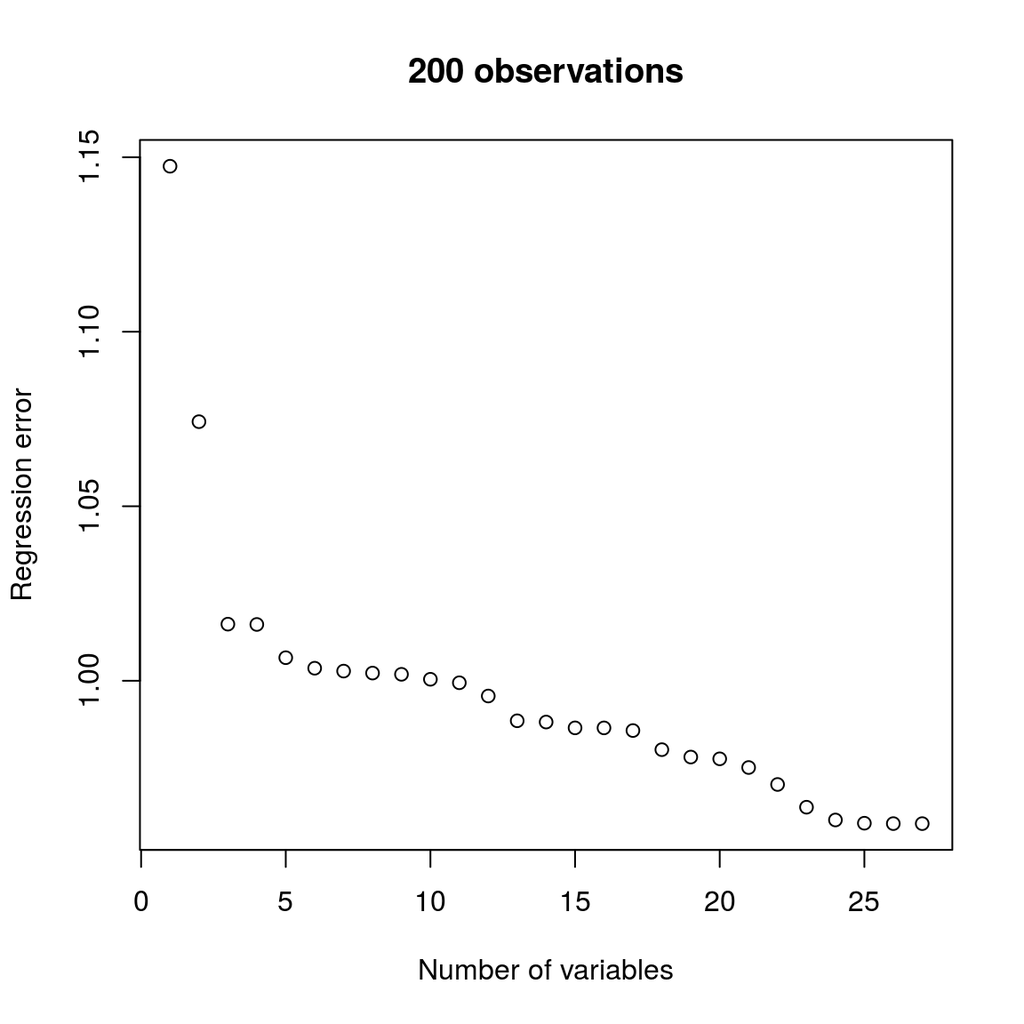

```r
simDat <- simuLinQuadDat(inpNobs=200, inpNlinVars=6, inpYidx=1:3, inpSDerr=1)
df2plot <- NULL
for ( iTmp in 2:dim(simDat)[2] ) {
  lmTmp <- lm(Y~.,simDat[,1:iTmp])
  errTmp <- sqrt(mean((simDat[,"Y"]-predict(lmTmp))^2))
  df2plot <- rbind(df2plot,data.frame(nvars=iTmp-1,err=errTmp))
}
plot(df2plot,xlab="Number of variables",ylab="Regression error",main=paste(dim(simDat)[1],"observations"))
```

As one would expect, inclusion of the first three predictors (average of which plus noise *is* the outcome) results in the most dramatic decrease in the average quadratic difference between observed and predicted outcome (that is training error, of course – because it is calculated on the same dataset that the model was fit to), followed by the gradual decrease in the error as more model terms are incorporated. Here, we pretend to know which predictors are the most important and have to be included first and in which order the rest of them have to be added. More disciplined approaches involve ordering predictors by their corresponding model improvement at each step of variable selection. We use this shortcut for the purposes of simplicity to allow us to focus on resampling and the difference between training and test errors.

Two more caveats due here concern the notion of the degrees of freedom. First, once again for simplicity, the training error as calculated above is different from `sigma` slot in the output of `summary()` by $\sqrt{n/(n-p-1)}$ where $n$ is the number of observations and $p$ – number of the variables included in the model (aka degrees of freedom used up by the model). For more details, see for instance, corresponding section in [LHSP](http://www.jerrydallal.com/LHSP/dof.htm) – that is a great source of all kinds of practical statistical wisdom. Second, as the number of variables included in the model approaches about 10-20, for a given number of observations ($n=200$) it starts to exceed maximal recommended ratio of the number of observations to the number of predictors included in the model, that is also about 10-20 for the kind of signal/noise ratios typically encountered in biomedical and social sciences. In other words, fitting model with 27 variables on 200 observations is generally a bad idea, but we will see below that the discrepancy between training and test error for our examples kicks in way before that.

Back to the demo – the plot above demonstrates that the training error continues to decrease as the model complexity increases. How the training and test errors would look like if model is trained on a bootstrap of the data and tested on the subset of the data not included in the bootstrap? First, again, let’s write a function evaluating inclusion of one to all predictors over a number of bootstraps. For the purposes of clarity and simplicity here we disregard existing bootstrap facilities that are available in R in packages such as `boot` and implement simple bootstrap resampling directly:

```r
bootTrainTestErrOneAllVars <- function(inpDat,nBoot=100) {
  # matrices and vector to store bootstrap training
  # and test errors as well as training error for model
  # fit on all observations -- for one through all
  # variables in the dataset:
  errTrain <- matrix(NA,nrow=nBoot,ncol=dim(inpDat)[2]-1)
  errTest <- matrix(NA,nrow=nBoot,ncol=dim(inpDat)[2]-1)
  allTrainErr <- numeric()
  # first predictor is the second column in
  # the input data - first is the outcome "Y":
  for ( iTmp in 2:dim(inpDat)[2] ) {
    # fit model and calculate error on all observations:
    lmTmp <- lm(Y~.,inpDat[,1:iTmp])
    # summary(lmTmp)$sigma for degrees of freedom correction
    allTrainErr[iTmp-1] <- sqrt(mean((inpDat[,"Y"]-predict(lmTmp))^2))
    # draw repeated boostraps of the data:
    for ( iBoot in 1:nBoot ) {
      # replace=TRUE is critical for bootstrap to work correctly:
      tmpBootIdx <- sample(dim(inpDat)[1],dim(inpDat)[1],replace=TRUE)
      # model fit on the bootstrap sample and
      # corresponding training error:
      lmTmpBoot <- lm(Y~.,inpDat[tmpBootIdx,1:iTmp])
      # summary(lmTmpBoot)$sigma for degrees of freedom correction
      errTrain[iBoot,iTmp-1] <- sqrt(mean((inpDat[tmpBootIdx,"Y"]-predict(lmTmpBoot))^2))
      # test error is calculated on the observations
      # =not= in the bootstrap sample - thus "-tmpBootIdx"
      errTest[iBoot,iTmp-1] <- sqrt(mean((inpDat[-tmpBootIdx,"Y"]-predict(lmTmpBoot,newdata=inpDat[-tmpBootIdx,1:iTmp]))^2))
    }
  }
  # return results as different slots in the list:
  list(bootTrain=errTrain,bootTest=errTest,allTrain=allTrainErr)
}
```

Let’s calculate training and test bootstrap errors (as well as training error on all observations) on the dataset we have already generated previously and plot them as function of the number of variables in the model:

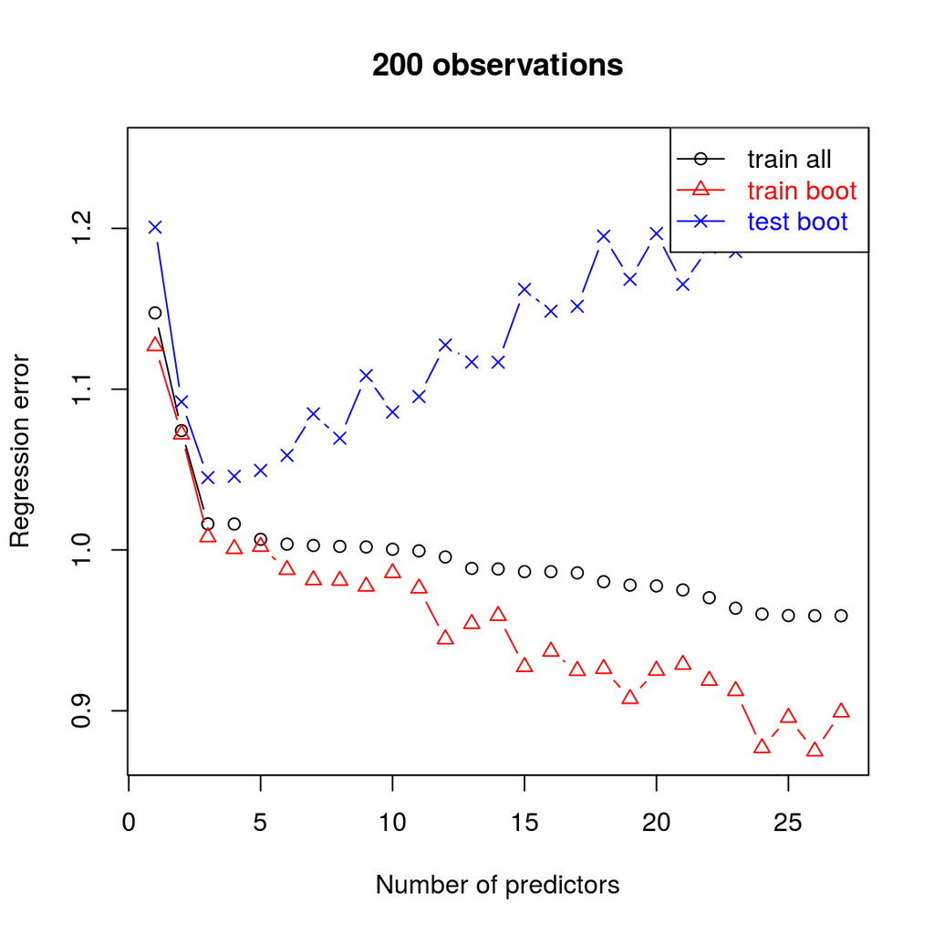

```r
# wrapper for plotting:
plotBootRegrErrRes <- function(inpRes,inpPchClr=c(1,2,4),mainTxt="") {
  matplot(1:length(inpRes$allTrain),cbind(inpRes$allTrain,colMeans(inpRes$bootTrain),colMeans(inpRes$bootTest)),pch=inpPchClr,col=inpPchClr,lty=1,type="b",xlab="Number of predictors",ylab="Regression error",main=mainTxt)
  legend("topright",c("train all","train boot","test boot"),col=inpPchClr,text.col=inpPchClr,pch=inpPchClr,lty=1)
}
bootErrRes <- bootTrainTestErrOneAllVars(simDat,30)
plotBootRegrErrRes(bootErrRes,mainTxt="200 observations")
```

Notice how test error starts to increase once all variables truly associated with the outcome has been already included in the model, while training errors continue to decrease reflecting overfit (and increasing contribution of the variance term to the model error).

Lastly, let’s repeat this exercise for two larger numbers of observations simulated under the same conditions:

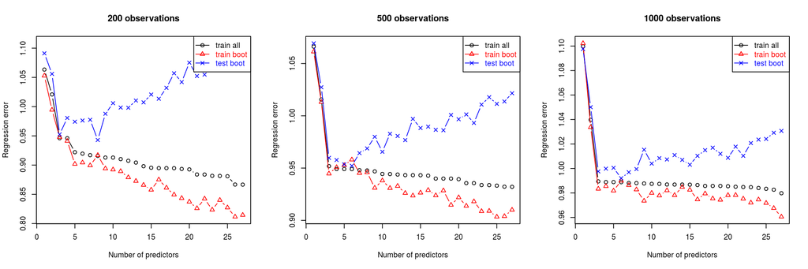

```r
old.par <- par(mfrow=c(1,3))
for ( tmpNobs in c(200,500,1000) ) {
  simDat <- simuLinQuadDat(inpNobs=tmpNobs, inpNlinVars=6, inpYidx=1:3, inpSDerr=1)
  bootErrRes <- bootTrainTestErrOneAllVars(simDat,30)
  plotBootRegrErrRes(bootErrRes,mainTxt=paste(tmpNobs,"observations"))
}
```

```r
par(old.par)
```

Notice how the increase in test error with the number of predictors becomes less pronounced for larger numbers of observations.

To conclude, the examples above present code and analyses that are very close to what you will need to complete this week problem set. Please feel free to start with those examples and modify them as necessary. And, as always, do ask questions if anything seems unclear.

# Problem: estimating multiple regression error rate by resampling (60 points)

This week problem set closely follows what is explained in the preface above, except that instead of using simulated dataset, you are expected to use dataset on CPU performance (from the 80s) available at UCI ML data archive (https://archive.ics.uci.edu/ml/datasets/Computer+Hardware) as well as on this course website in canvas (file `machine.data` there). It is probably the best to download and use local copy on your computer.

The first two columns – vendor and model names – are irrelevant for the regression task. The continuous (this is regression problem) outcome that we will model is PRP. One of the continuous attributes in the dataset – ERP, very highly correlated with PRP – is a result of modeling PRP by the dataset contributors and has to be discarded as well. In the end you should be working with a dataset with seven continuous attributes – one outcome, PRP and six predictors (MYCT, MMIN, MMAX, CACH, CHMIN and CHMAX to use data contributors’ notation). Due to non-linearity affecting multiple attributes in this dataset, you are better off working with log transformed *both* predictors and the outcome – because several values in this dataset are zeroes and to avoid dealing with NaNs just add “1” before log-transform to all values in this dataset (e.g. `cpuDat <- log(cpuDat+1)`).

## Sub-problem 1: read in the dataset and provide numerical and graphical summaries (10 points)

Use methods such as `summary` and `pairs` that have been used in the previous problem sets. Comment on the extent of the signal available in the data for modeling PRP. Rearrange columns in the dataset in the decreasing order of absolute values of their correlation with the outcome (PRP). So that PRP is the first column, the next one is the predictor that is most (positively or negatively) correlated with it, and so on. You may find it convenient to use R function `order` for that.

```r
cpuDat = read.csv("machine.data")
# rename dataframe columns
attribNames = c("Vendor Name", "Model Name", "MYCT", "MMIN", "MMAX", "CACH", "CHMIN", "CHMAX", "PRP", "ERP")
colnames(cpuDat) = attribNames
# summary
summary(cpuDat)
```

```
##     Vendor Name       Model Name       MYCT             MMIN
##  ibm      : 32   100       :  1   Min.   :  17.0   Min.   :   64
##  nas      : 19   1100/61-h1:  1   1st Qu.:  50.0   1st Qu.:  768
##  honeywell: 13   1100/81   :  1   Median : 110.0   Median : 2000
##  ncr      : 13   1100/82   :  1   Mean   : 204.2   Mean   : 2881
##  sperry   : 13   1100/83   :  1   3rd Qu.: 225.0   3rd Qu.: 4000
##  siemens  : 12   1100/84   :  1   Max.   :1500.0   Max.   :32000
##  (Other)  :106   (Other)   :202
##       MMAX            CACH           CHMIN            CHMAX
##  Min.   :   64   Min.   :  0.0   Min.   : 0.000   Min.   :  0.00
##  1st Qu.: 4000   1st Qu.:  0.0   1st Qu.: 1.000   1st Qu.:  5.00
##  Median : 8000   Median :  8.0   Median : 2.000   Median :  8.00
##  Mean   :11824   Mean   : 24.1   Mean   : 4.644   Mean   : 17.74
##  3rd Qu.:16000   3rd Qu.: 32.0   3rd Qu.: 6.000   3rd Qu.: 24.00
##  Max.   :64000   Max.   :256.0   Max.   :52.000   Max.   :176.00
##
##       PRP              ERP
##  Min.   :   6.0   Min.   :  15.00
##  1st Qu.:  27.0   1st Qu.:  28.00
##  Median :  49.5   Median :  45.00
##  Mean   : 105.2   Mean   :  98.85
##  3rd Qu.: 111.5   3rd Qu.:  99.50
##  Max.   :1150.0   Max.   :1238.00
##
```

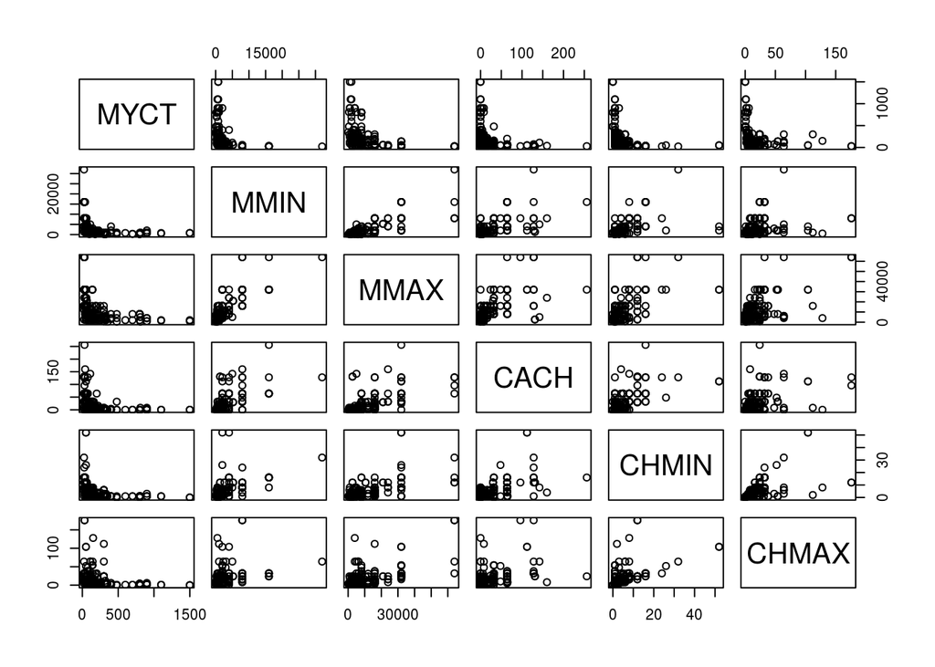

```r
# XY-scatterplot of the predictors
pairs(x=cpuDat[, c("MYCT", "MMIN", "MMAX", "CACH", "CHMIN", "CHMAX")])
```

The XY-scatterplots for the original predictors and outcome do not show much by way of relationships. Instead, the continous variables will be log-transformed below to find any underlying linear relations (collinearity) between the predictors.

```r
# log transforming cpuDat
logCpuDat = log(cpuDat[,3:10]+1)
# summary of the log-transformed data
summary(logCpuDat)
```

```
##       MYCT            MMIN             MMAX             CACH
##  Min.   :2.890   Min.   : 4.174   Min.   : 4.174   Min.   :0.000
##  1st Qu.:3.932   1st Qu.: 6.645   1st Qu.: 8.294   1st Qu.:0.000
##  Median :4.710   Median : 7.601   Median : 8.987   Median :2.197
##  Mean   :4.760   Mean   : 7.370   Mean   : 8.924   Mean   :2.059
##  3rd Qu.:5.421   3rd Qu.: 8.294   3rd Qu.: 9.680   3rd Qu.:3.497
##  Max.   :7.314   Max.   :10.374   Max.   :11.067   Max.   :5.549
##      CHMIN            CHMAX            PRP             ERP
##  Min.   :0.0000   Min.   :0.000   Min.   :1.946   Min.   :2.773
##  1st Qu.:0.6931   1st Qu.:1.792   1st Qu.:3.332   1st Qu.:3.367
##  Median :1.0986   Median :2.197   Median :3.922   Median :3.829
##  Mean   :1.3481   Mean   :2.396   Mean   :4.058   Mean   :4.062
##  3rd Qu.:1.9459   3rd Qu.:3.219   3rd Qu.:4.723   3rd Qu.:4.610
##  Max.   :3.9703   Max.   :5.176   Max.   :7.048   Max.   :7.122
```

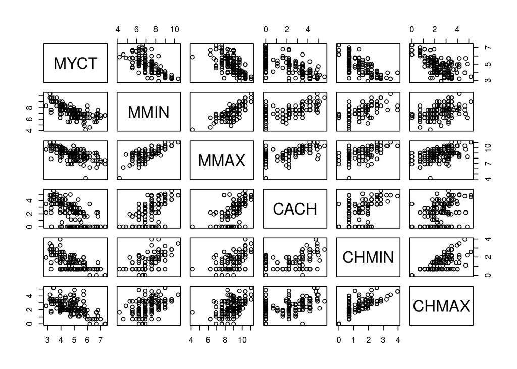

```r
# XY-scatter plots of the predictors
pairs(x=logCpuDat[, c("MYCT", "MMIN", "MMAX", "CACH", "CHMIN", "CHMAX")])
```

```r
# correlation matrix for PRP and predictors
cor(logCpuDat[,1:7])
```

```
##             MYCT       MMIN       MMAX       CACH      CHMIN      CHMAX
## MYCT   1.0000000 -0.7326865 -0.6326961 -0.6238184 -0.6226729 -0.5599282
## MMIN  -0.7326865  1.0000000  0.7364719  0.6273006  0.5943904  0.4703473
## MMAX  -0.6326961  0.7364719  1.0000000  0.6249010  0.4916800  0.5225642
## CACH  -0.6238184  0.6273006  0.6249010  1.0000000  0.5132877  0.4791791
## CHMIN -0.6226729  0.5943904  0.4916800  0.5132877  1.0000000  0.7040854
## CHMAX -0.5599282  0.4703473  0.5225642  0.4791791  0.7040854  1.0000000
## PRP   -0.7030776  0.7819787  0.7992505  0.7666508  0.6718174  0.6373905
##              PRP
## MYCT  -0.7030776
## MMIN   0.7819787
## MMAX   0.7992505
## CACH   0.7666508
## CHMIN  0.6718174
## CHMAX  0.6373905
## PRP    1.0000000
```

```r
# correlation of the new log-transformed predictors and PRP
cr = cor(logCpuDat[,1:7], y=logCpuDat$PRP)
colnames(cr) = "Correlation with log(PRP)"
cr
```

```
##       Correlation with log(PRP)
## MYCT                 -0.7030776
## MMIN                  0.7819787
## MMAX                  0.7992505
## CACH                  0.7666508
## CHMIN                 0.6718174
## CHMAX                 0.6373905
## PRP                   1.0000000
```

The ordering from highest to lowest absolute value for correlation between the outcome (PRP) and the predictor: MMAX, MMIN, CACH, MYCT, CHMIN, and CHMAX.

```r
# create new dataset with log-transformed
corPred = cor(logCpuDat[, 1:7], y=logCpuDat$PRP)
cpuData = logCpuDat[,order(abs(corPred), decreasing=TRUE)]
```

After looking at the correlation between PRP and the predictors for the log-transfomration, we find that MMAX, MMIN, and CACH are the top three predictors correlated with PRP. These may prove to be important predictors when designing a regression model. It is also interesting to note that MYCT and MMIN have a high correlation (-0.7326865) with each other. We will see how these predictors interact with one another and the model. Lastly, MYCT is the only predictor negatively correlated with PRP.

## Sub-problem 2: add quadratic terms to the dataset (10 points)

Use the code presented in the preface as a template to develop your own procedure for adding to the computer hardware dataset containing outcome (PRP) and all continuous predictors (MYCT through CHMAX) all pairwise products of continuous predictors (e.g. MYCT x MYCT, MYCT x MMIN, …, CHMAX x CHMAX). The data used here has to be the one from computer hardware dataset, *not* simulated from normal distribution. In the end your dataset should have 28 columns: PRP, 6 predictors and 6*7/2=21 of their pairwise combinations.

```r
# function to create the quadratic predictors
createQuadraticPred = function(df) {
  copyDf = data.frame(df)
  colNam = colnames(df)
  for(ic in 2:dim(df)[2]){
    for(jc in ic:dim(df)[2]){
      newCol = df[,ic]*df[,jc]
      colNam = c(colNam, paste(colnames(cpuData)[ic], colnames(cpuData)[jc], sep=" x ", collapse=NULL))
      copyDf = cbind(copyDf, newCol)
    }
  }
  colnames(copyDf) = colNam
  copyDf
}
# test function
newCpuData = createQuadraticPred(cpuData)
# dimensions of rows and columns
dim(newCpuData)
```

```
## [1] 208  28
```

## Sub-problem 3: fit multiple regression models on the entire dataset (10 points)

As illustrated in the preface above, starting from the first, most correlated with PRP, predictor, fit linear models with one, two, …, all 27 linear and quadratic terms on the entire dataset and calculate resulting (training) error for each of the models. Plot error as a function of the number of predictors in the model (similar to the plot in the preface that shows just the training error on the entire dataset). Because the underlying data is different the plot you obtain here for computer hardware dataset will be different from that shown in the preface. Please comment on this difference.

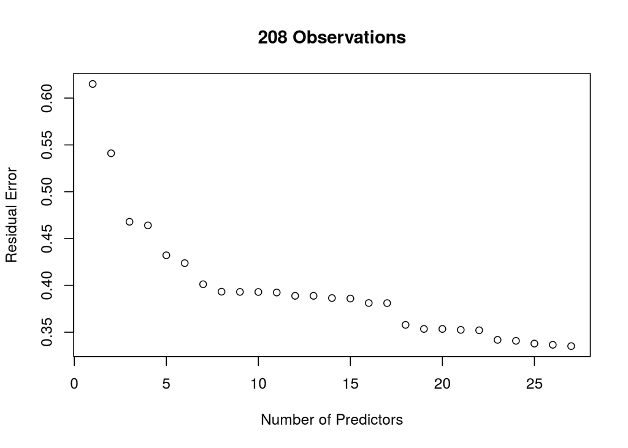

```r
# code segment to predict error and graph, based on the function above
pE = numeric() # vector for predicted error
for(ic in 2:dim(newCpuData)[2]){
  fit = lm(newCpuData$PRP~., newCpuData[, 1:ic])
  err = sqrt(mean((newCpuData[,1]-predict(fit))^2))
  pE = c(pE, err)
}
plot(pE, xlab="Number of Predictors", ylab="Residual Error", main="208 Observations")
```

## Sub-problem 4: develop function performing bootstrap on computer hardware dataset (10 points)

Modify function `bootTrainTestErrOneAllVars` defined in the preface to perform similar kind of analysis on the computer hardware dataset. Alternatively, you can determine what modifications are necessary to the computer hardware dataset, so that it can be used as input to `bootTrainTestErrOneAllVars`.

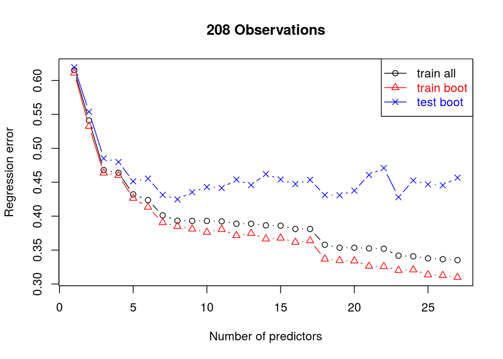

```r
# using the bootTrainTEstErrOneAllVars function from above on the cpuData
colnames(newCpuData)[1] = "Y" # one modification to set the PRP column name to Y
bootRes = bootTrainTestErrOneAllVars(newCpuData) # boostrap with the default nBoot=100 (100 boostrap obs)
plotBootRegrErrRes(bootRes, main="208 Observations") # plot just to test that the function works
```

In order to use the bootTrainTestErrOneAllVars properly, a modification needed to be made to the name of the first column for cpuData. The PRP column name must be modified to “Y” in order to be accepted into the function and complete with no errors. Once this is done, the original function can be used.

## Sub-problem 5: use bootstrap to estimate training and test error on computer hardware dataset (20 points)

Use function developed above to estimate training and test error in modeling PRP on the computer hardware dataset. Plot and discuss the results. Compare model error over the range of model complexity to that obtained by the dataset contributors (as a difference between ERP and PRP in the original full dataset once the log-transform performed before proceeding with modeling here has been accounted for – by either calculating error on log-transform of PRP and ERP or transforming our model predictions back to the original scale of PRP measurements)

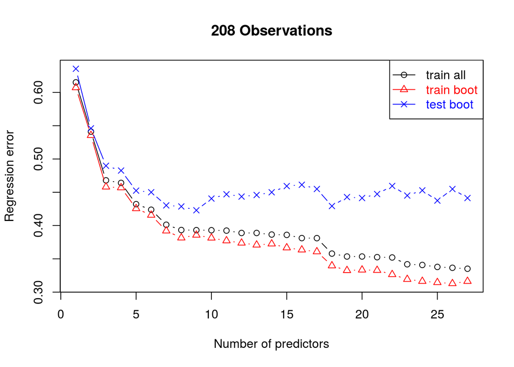

```r
# This is a repeat of the code above. The plot above was used to test that the modification to the cpuData would allow it to run sucessfully in the function
colnames(newCpuData)[1] = "Y" # one modification to set the PRP column name to Y
bootRes = bootTrainTestErrOneAllVars(newCpuData) # nBoot=100
plotBootRegrErrRes(bootRes, main="208 Observations")
```

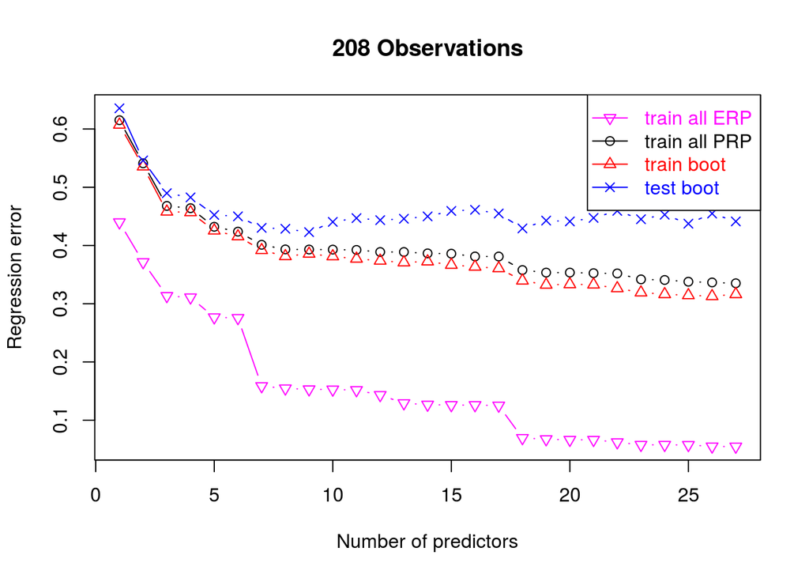

```r
# creating the regression error of ERP
logERP = log(cpuDat$ERP+1) # log-transform ERP
cpuDataWithERP = newCpuData[,2:dim(newCpuData)[2]] # replace PRP with ERP
cpuDataWithERP = cbind(logERP, cpuDataWithERP)
colnames(cpuDataWithERP)[1] = "ERP"

# calculate Residual Errors with ERP
predErr = numeric() # vector for predicted error
for(ic in 2:dim(cpuDataWithERP)[2]){
  fit = lm(cpuDataWithERP$ERP~., cpuDataWithERP[, 1:ic])
  err = sqrt(mean((cpuDataWithERP[,1]-predict(fit))^2)) # RMSE for ERP
  predErr = c(predErr, err)
}
bootRes[["Train with ERP"]] = predErr

# modify the bootstrap plot to include the ERP errors
plotBootRegrErrResMod <- function(inpRes,res2, inpPchClr=c(6,1,2,4),mainTxt="") {
  matplot(1:length(inpRes$allTrain),cbind(res2, inpRes$allTrain,colMeans(inpRes$bootTrain),colMeans(inpRes$bootTest)),pch=inpPchClr,col=inpPchClr,lty=1,type="b",xlab="Number of predictors",ylab="Regression error",main=mainTxt)
  legend("topright",c("train all ERP","train all PRP","train boot","test boot"),col=inpPchClr,text.col=inpPchClr,pch=inpPchClr,lty=1)
}
plotBootRegrErrResMod(bootRes, predErr, main="208 Observations")
```

The ERP regression error line has much lower error overall for each predictor compared to the PRP regression error line. But their data and predictions only provide an estimate model of which predictors minimize error for true RP (relative performance). We see that there is a very large discrepency of error between the test boostrap and train all ERP. Although the bootstrap was not run with ERP, it still shows that the ERP model for predictors has a high level of bias and overfitting. For instance, if we created a regression model with the suggested train all ERP predictors, the fit would likely follow the training data better than a test set. So while the predicting with ERP reduces more error, training with PRP has less bias and may fair better with test data.

## Extra points problem: using centered and scaled predictor values (5 points)

Given the undesirable effects of having highly correlated predictors in the model (for the reasons of collinearity, variance inflation, etc.) it would be more adviseable to center and scale predictors in this dataset prior to creating higher order terms. There is a function `scale` in R for that. Please explore the effect of using such transformation. You should be able to demonstrate that it does decrease correlations between predictors (including their products) while it has very little impact on the performance of the resulting models in terms of training/test error. If you think carefully about what is necessary here, the required change could be as small as adding one (optional) call to `scale` placed strategically in the code and then compiling and comparing results with and without executing it.

```r
# original non-scaled correlation matrix
cor(cpuData)
```

```
##              PRP       MMAX       MMIN       CACH       MYCT      CHMIN
## PRP    1.0000000  0.7992505  0.7819787  0.7666508 -0.7030776  0.6718174
## MMAX   0.7992505  1.0000000  0.7364719  0.6249010 -0.6326961  0.4916800
## MMIN   0.7819787  0.7364719  1.0000000  0.6273006 -0.7326865  0.5943904
## CACH   0.7666508  0.6249010  0.6273006  1.0000000 -0.6238184  0.5132877
## MYCT  -0.7030776 -0.6326961 -0.7326865 -0.6238184  1.0000000 -0.6226729
## CHMIN  0.6718174  0.4916800  0.5943904  0.5132877 -0.6226729  1.0000000
## CHMAX  0.6373905  0.5225642  0.4703473  0.4791791 -0.5599282  0.7040854
##            CHMAX
## PRP    0.6373905
## MMAX   0.5225642
## MMIN   0.4703473
## CACH   0.4791791
## MYCT  -0.5599282
## CHMIN  0.7040854
## CHMAX  1.0000000
```

```r
# new data set with scaled cpuData (cpuData is already log-transformed)
scaledCpuData = scale(cpuData)
cor(scaledCpuData) # cor matrix to compare with non-scaled data
```

```
##              PRP       MMAX       MMIN       CACH       MYCT      CHMIN
## PRP    1.0000000  0.7992505  0.7819787  0.7666508 -0.7030776  0.6718174
## MMAX   0.7992505  1.0000000  0.7364719  0.6249010 -0.6326961  0.4916800
## MMIN   0.7819787  0.7364719  1.0000000  0.6273006 -0.7326865  0.5943904
## CACH   0.7666508  0.6249010  0.6273006  1.0000000 -0.6238184  0.5132877
## MYCT  -0.7030776 -0.6326961 -0.7326865 -0.6238184  1.0000000 -0.6226729
## CHMIN  0.6718174  0.4916800  0.5943904  0.5132877 -0.6226729  1.0000000
## CHMAX  0.6373905  0.5225642  0.4703473  0.4791791 -0.5599282  0.7040854
##            CHMAX
## PRP    0.6373905
## MMAX   0.5225642
## MMIN   0.4703473
## CACH   0.4791791
## MYCT  -0.5599282
## CHMIN  0.7040854
## CHMAX  1.0000000
```

```r
# create the quadratic predictors with scaled data
scaledCpuDataQuad = createQuadraticPred(scaledCpuData)

# comparison of quadratic predictor correlation
cor(newCpuData$`MMAX x MMAX`, newCpuData$`MMAX x MMIN`) # not scaled cor
```

```
## [1] 0.9101905
```

```r
cor(scaledCpuDataQuad$`MMAX x MMAX`, scaledCpuDataQuad$`MMAX x MMIN`) # scaled cor
```

```
## [1] 0.8960645
```

```r
cor(newCpuData$`CACH x MYCT`, newCpuData$`CHMIN x CHMIN`)
```

```
## [1] 0.3768125
```

```r
cor(scaledCpuDataQuad$`CACH x MYCT`, scaledCpuDataQuad$`CHMIN x CHMIN`)
```

```
## [1] -0.3705254
```

```r
# shows the mean absolute difference between the non-scaled correlations and scaled correlation
diffCor = abs(cor(newCpuData)) - abs(cor(scaledCpuDataQuad))
meanDiffCorr = mean(diffCor)
meanDiffCorr # MAD for non-scaled and scaled correlations
```

```
## [1] 0.2265181
```

```r
# comparing MAD for scaled before Quadratic predictors added vs. scaled after Quadratic predictors added
scaAfterQuadAdd = scale(newCpuData)
scaBeforeQuadAdd = scaledCpuDataQuad
# scaling before or after adding Quadratic predictors lowers collinearity
mean(abs(cor(scaBeforeQuadAdd))-abs(cor(scaAfterQuadAdd)))
```

```
## [1] -0.2265181
```

Based on the application of the scale() function to the data, there are a few interesting changes to the data. First, we see that the single variable predictors (MYCT, MMIN, MMAX, etc.) do not change in correlation; this is why we see the same correlation matrix values before and after scaling. This is because scale() normalizes the data, but does not change the underlying relationships between the predictors with each other and predictors with the outcome.

The change in predictor correlation comes after the quadratic predictors are generated. We see that correlation decreases for quadratic predictors in the scaled data. The two tests for quadratic correlations showed an absolute decrease between the original data and the scaled data. Further, we compared the mean absolute difference of the correlation matricies for non-scaled data and scaled data. The MAD was 0.2265181 for the difference between original and scaled. This means the original data had higher correlations on average among the predictors than scaled data. Or conversely, scaling the data allowed us to lower the correlations among the quadratic predictors and control for multicollinearity.